# IODS course project

# Chapter 3: Joining data and Logistic regression

*Key words: merging data, creating variables within a for loop, logistic regression, cross validation with binary predictions (training and test sets)*

Reading in the data `alc` that we wrangled from the data described [here](https://archive.ics.uci.edu/ml/datasets/STUDENT+ALCOHOL+CONSUMPTION). The data is related to secondary school student alcohol comsumption in Portugal, based on two identical questionnaires: one related to a mathematics class and the other to a portuguese class.

```r
alc<-read.table("./data/alc.txt", sep="\t", header=T, dec=".")
names(alc)
```

```
##  [1] "school"     "sex"        "age"        "address"    "famsize"
##  [6] "Pstatus"    "Medu"       "Fedu"       "Mjob"       "Fjob"
## [11] "reason"     "nursery"    "internet"   "guardian"   "traveltime"
## [16] "studytime"  "failures"   "schoolsup"  "famsup"     "paid"
## [21] "activities" "higher"     "romantic"   "famrel"     "freetime"
## [26] "goout"      "Dalc"       "Walc"       "health"     "absences"
## [31] "G1"         "G2"         "G3"         "alc_use"    "high_use"
```

### High/ low alcohol consumption

To investigate factors associated with high/ low alcohol consumption I chose the following four variables:

1. **sex** (binary: ‘F’ - female or ‘M’ - male)
2. **address** (binary: ‘U’ - urban or ‘R’ - rural)
3. **weekly studytime** (numeric: 1 - <2 hours, 2 - 2 to 5 hours, 3 - 5 to 10 hours, or 4 - >10 hours)
4. **mother’s job** (nominal: ‘teacher’, ‘health’ care related, civil ‘services’ (e.g. administrative or police), ‘at_home’ or ‘other’)

I chose these variables as a wanted to have a mixture of binary, ordinal and categorical variables and I felt like these variables might well be associated with alcohol use.

#### Preliminary Hypotheses

My hypothesis (based on previous knowledge and intuition) is that men will be more prone to high consumption than women, students from rural areas will be more prone to high consumption, study time will be negatively correlated (i.e. the more you study the more likely you are to be a low consumer of alcohol), and that there will not be great differences between students with mother’s working in different job categories. The minor differences for this last variable might be such that those with mother’s working for civil services or belonging to category “other” will be more likely to be high consumers of alcohol than those with mothers working as teachers, in the health care or at home.

#### Variable distributions and general assessment of variable relations with alcohol consumption

Based on the below summary statistics and the barplots of the individual variables seen on the diagonal of the pairwise plot(Figure 2), luckily the magority of the students do not fall under the category high consumers of alcohol. High consumers of alcohol only constitute 30% of the data. The sex ratio is almost 1:1, with females taking the lead. Only less than 1/4 of the students live in the rural areas as opposed to the urban areas. The category “Other” is the most popular answer for mother’s job, services being the second most common and health the least. Studytime per week has been categorized into 4 ordinal groups the two lowest categories getting most of the values.

Paying attention to the blue and red colours representing high and low consumption of alcohol respectively in the Figure 2, we note from the diagonal plots that address, sex and studytime, seem to be associated with consumption status. Based on the boxplots (better boxplots lower down, Figure 3) studytime seems to be clearly associated with alcohol consumption: High consumers spend less time studying per week than non-high users. This pattern can be seen irrespective of address and mainly mother’s job. Nevertheless, for men this pattern does not apply as they seem to study less than women as a whole, irrespective of their alcohol consumption.

These associations are in line with my original hypotheses.

```r
###Relationship between high/low alcohol consumption and 4 variables
##Distributions of variables and visual inspection of associations

summary(alc[,c("high_use","sex","address","Mjob","studytime")])
```

```
##   high_use       sex     address       Mjob       studytime
##  Mode :logical   F:198   R: 81   at_home : 53   Min.   :1.000
##  FALSE:268       M:184   U:301   health  : 33   1st Qu.:1.000
##  TRUE :114                       other   :138   Median :2.000
##  NA's :0                         services: 96   Mean   :2.037
##                                  teacher : 62   3rd Qu.:2.000
##                                                 Max.   :4.000
```

```r
percent_highalc<-114/382; percent_highalc
```

```
## [1] 0.2984293
```

```r
str(alc[,c("high_use","sex","address","Mjob","studytime")])
```

```
## 'data.frame':    382 obs. of  5 variables:
##  $ high_use : logi  FALSE TRUE FALSE FALSE TRUE FALSE ...
##  $ sex      : Factor w/ 2 levels "F","M": 1 1 1 1 1 1 1 1 1 1 ...
##  $ address  : Factor w/ 2 levels "R","U": 1 1 1 1 1 1 1 1 1 2 ...
##  $ Mjob     : Factor w/ 5 levels "at_home","health",..: 1 3 1 4 4 4 4 2 3 3 ...
##  $ studytime: int  4 2 1 3 3 3 3 2 4 4 ...
```

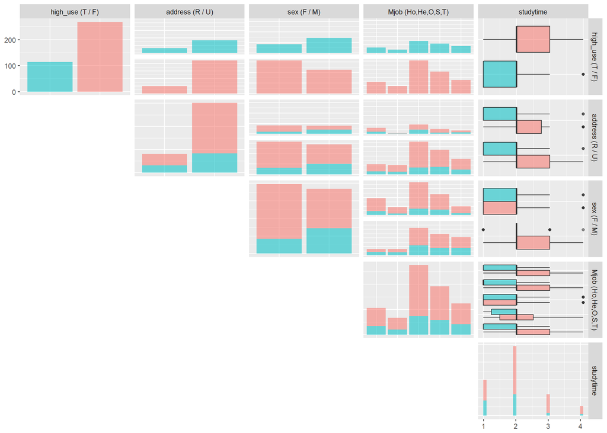

*Figure 2:Pairwise plot of all variables by alcohol use (blue=T, red=F), NOTE: the axis tick labels stated in the brackets are in the correct order at the top of the graph, but not at the right of the graph!*

```r
# accessig the GGally and ggplot2 libraries
library(GGally)
library(ggplot2)

# Drawing pairwise plots of the variables to be looked at

alc$high_usef<-as.factor(ifelse(alc$high_use==T, "high", "low"))
ggpairs(alc, columns=c("high_usef","address","sex","Mjob","studytime"), diag=list(continuous="bar", discrete="bar"), lower=list(continuous="blank", discrete="blank", combo="blank"), axisLabels = "show", columnLabels =c("high_use (T / F)","address (R / U)","sex (F / M)","Mjob (Ho,He,O,S,T)","studytime") , mapping = aes(col=high_use,alpha=0.3)) #sadly I couldn't find a way to get the axis tick labels nicely visible  :(
```

#### More scrutinous visual assessments and crosstabulations of possible associations

Below more clear plots of the boxplots that were already presented in the pairwise plot matrix and that I already commented.

##### Boxplots

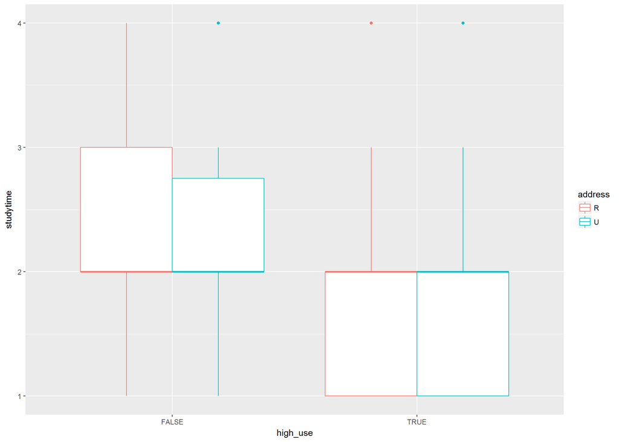

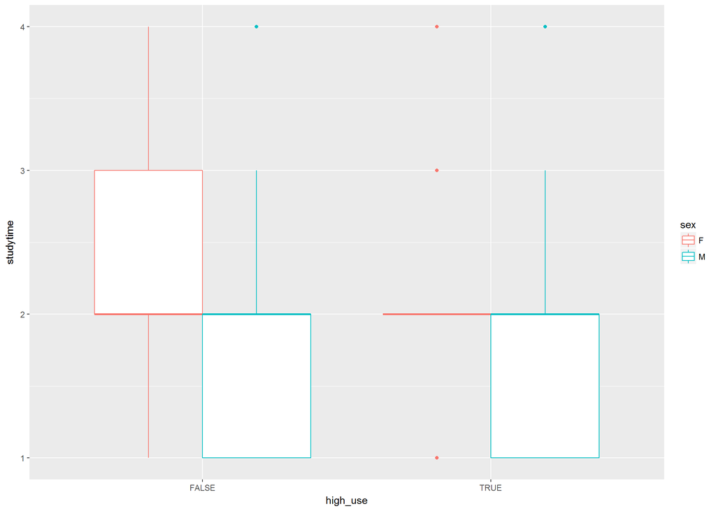

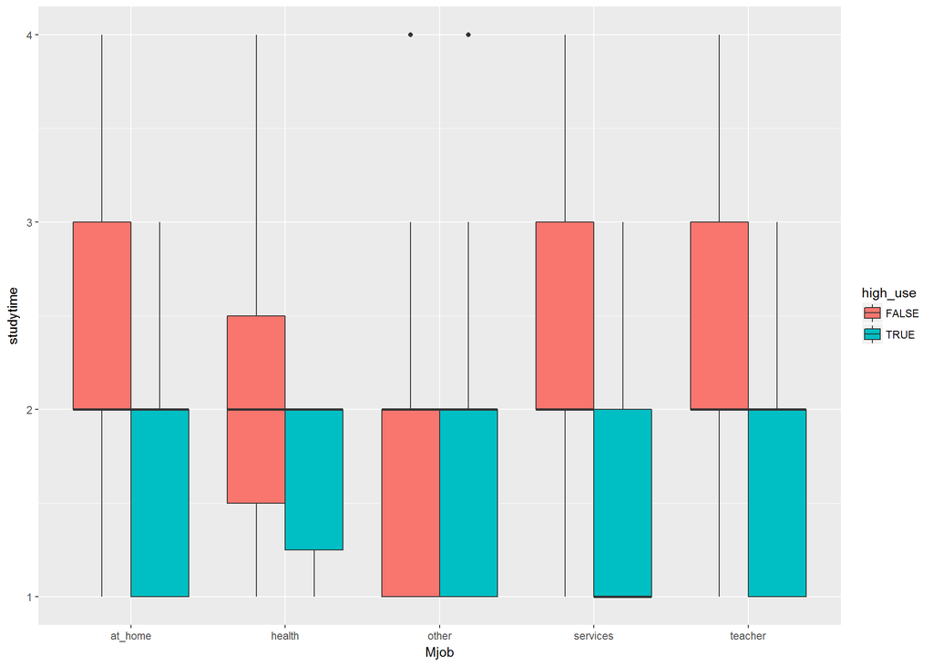

*Figure 3:Box plots of studytime by alcohol use and the variables: address, sex and Mjob*

```r
###Boxplots
#Studytime
g1<-ggplot(data=alc, aes(x=high_use, y =studytime, col=address))
g1+geom_boxplot() + ylab("studytime") #studytime within address groups by drinking group

g1<-ggplot(data=alc, aes(x=high_use, y =studytime, col=sex))
g1+geom_boxplot() + ylab("studytime") #studytime within sex groups by drinking group


qplot(data=alc, x=Mjob, y=studytime, geom="boxplot", fill=high_use) #study time by drinking group within Mjob categories
```

##### Address: Rural/Urban

For fun, taking rural vs urban address into closer inspection. In my oppinion when comparing the two different ways of drawing the barplots, the first plot which corresponds to the second crosstabulation is more useful. Based on them, we note that for rural inhabitants there is a larger proportion of high drinkers than for urban inhabitants. The Second plot, corresponding to the first cross tabulation is less interesting as the data contains so many more students from urban areas as opposed to rural areas: for both the low consumers of alcohol, as well as for the high consumers of alcohol, the majority live in urban areas. Looking at the first cross tabulation closely we can also from this perspective note that the proportion of urban inhabitants is higher for low consumers than high consumers. This is all in line with my hypothesis of people living in rural areas consuming more alcohol than those living in urban areas.

```
##         address
## high_use   R   U
##    FALSE  50 218
##    TRUE   31  83
##         address
## high_use         R         U       Sum
##    FALSE 0.1865672 0.8134328 1.0000000
##    TRUE  0.2719298 0.7280702 1.0000000
##    Sum   0.4584970 1.5415030 2.0000000
##         address
## high_use         R         U       Sum
##    FALSE 0.6172840 0.7242525 1.3415364
##    TRUE  0.3827160 0.2757475 0.6584636
##    Sum   1.0000000 1.0000000 2.0000000
```

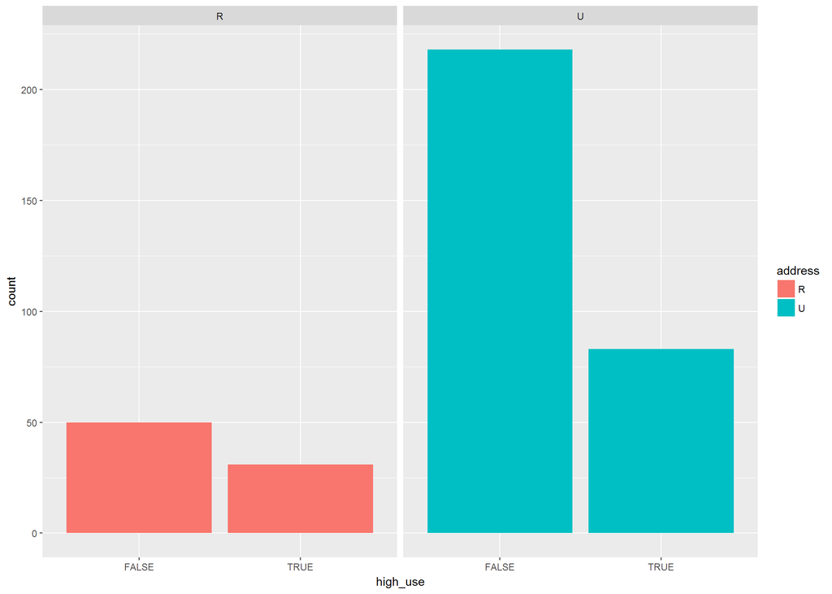

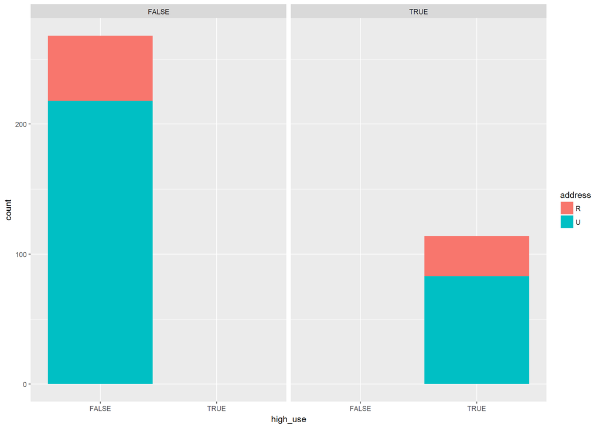

*Figure 4:Bar plots of address and alcohol consumption*

```r
###Relationship between high/low alcohol consumption and 4 variables
##Distributions of variables and visual inspection of associations

##Barplots
#address
g1<-ggplot(data=alc, aes(x=high_use,fill=address))
g1+geom_bar()+facet_wrap("address") #drinking distributions within R/U groups
g1+geom_bar()+facet_wrap("high_use") #address proportions within F/T high drinkers
table<-with(alc,table(high_use,address));table
addmargins(prop.table(table,1))#address distribution within false/true group
addmargins(prop.table(table,2)) #drinking distribution within R/U group
```

##### Mother’s job

To end with colour, as a last graphical inspection, plotting alcohol status by mother’s job. No remarkable differences between groups can be seen with respect to the student’s alcohol consumption. Looking at the minor differences, I note that the data seems to contradict my original hypothesis: based on these plots the groups other and services contain the highest proportions of low consumers.

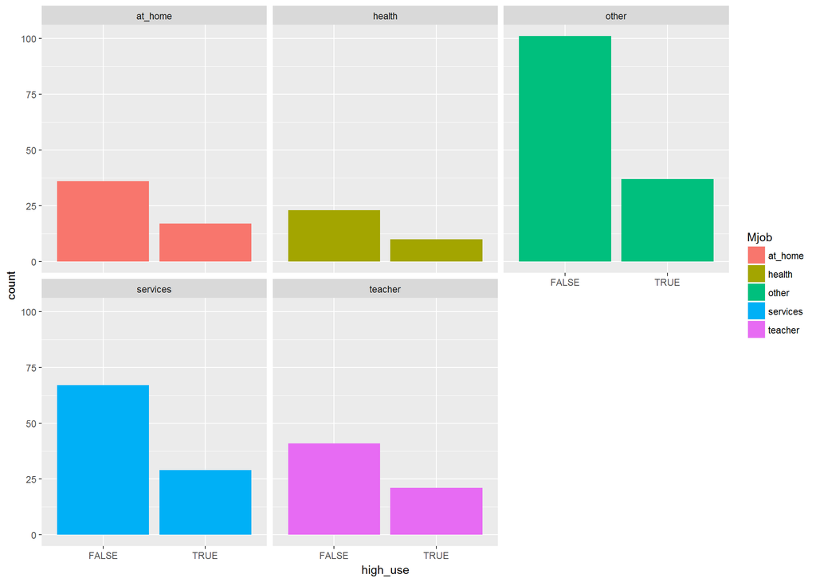

*Figure 5:Bar plot of mother’s job and alcohol consumption*

```r
#Mjob
g1<-ggplot(data=alc, aes(x=high_use,fill=Mjob))
g1+geom_bar()+facet_wrap("Mjob")
```

#### Logistic regression

```r
#logistic regression
m <- glm(high_use ~ sex + address + Mjob + studytime, data = alc, family = "binomial")
summary(m)
```

```
##
## Call:
## glm(formula = high_use ~ sex + address + Mjob + studytime, family = "binomial",
##     data = alc)
##
## Deviance Residuals:
##     Min       1Q   Median       3Q      Max
## -1.4076  -0.8746  -0.6340   1.2146   2.0603
##
## Coefficients:
##              Estimate Std. Error z value Pr(>|z|)
## (Intercept)    0.3571     0.4972   0.718  0.47262
## sexM           0.6620     0.2504   2.644  0.00820 **
## addressU      -0.5113     0.2804  -1.823  0.06825 .
## Mjobhealth    -0.1309     0.5093  -0.257  0.79709
## Mjobother     -0.3628     0.3729  -0.973  0.33058
## Mjobservices  -0.1774     0.3959  -0.448  0.65407
## Mjobteacher   -0.1069     0.4302  -0.248  0.80384
## studytime     -0.4926     0.1579  -3.119  0.00181 **
## ---
## Signif. codes:  0 '***' 0.001 '**' 0.01 '*' 0.05 '.' 0.1 ' ' 1
##
## (Dispersion parameter for binomial family taken to be 1)
##
##     Null deviance: 465.68  on 381  degrees of freedom
## Residual deviance: 435.94  on 374  degrees of freedom
## AIC: 451.94
##
## Number of Fisher Scoring iterations: 4
```

```r
# compute odds ratios (OR)
OR <- exp(coef(m))

# compute confidence intervals (CI)
CI<- exp(confint(m))

# print out the odds ratios with their confidence intervals
cbind(OR, CI)
```

```
##                     OR     2.5 %   97.5 %
## (Intercept)  1.4291691 0.5392894 3.814006
## sexM         1.9386020 1.1895417 3.180912
## addressU     0.5997205 0.3469055 1.044729
## Mjobhealth   0.8772712 0.3165916 2.361458
## Mjobother    0.6957037 0.3367947 1.462524
## Mjobservices 0.8374558 0.3867008 1.837041
## Mjobteacher  0.8986585 0.3863386 2.100119
## studytime    0.6110054 0.4439981 0.825917
```

#### Predictive power of the finalized logistic regression model

Next using, the variables that had a statistically significant relationship with alcohol consumption, I will explore the predictive power of my model.

```r
####
#logistic regression
m2 <- glm(high_use ~ sex + studytime, data = alc, family = "binomial")

# predict() the probability of high_use
alc$high_use_prob<- predict(m2, type = "response")

# use the probabilities to make a prediction of high_use
alc$high_use_pred <- alc$high_use_prob > 0.5

# see the last ten original classes, predicted probabilities, and class predictions
tail(alc[,c("high_use", "high_use_prob", "high_use_pred")])
```

```
##     high_use high_use_prob high_use_pred
## 377    FALSE     0.4795667         FALSE
## 378     TRUE     0.4795667         FALSE
## 379    FALSE     0.2602338         FALSE
## 380     TRUE     0.4795667         FALSE
## 381     TRUE     0.3627921         FALSE
## 382    FALSE     0.4795667         FALSE
```

```r
# tabulate the target variable versus the predictions
table(high_use = alc$high_use, prediction = alc$high_use_pred)
```

```
##         prediction
## high_use FALSE
##    FALSE   268
##    TRUE    114
```

```r
# seeing why we get so odd results
summary(alc$high_use_prob)
```

```
##    Min. 1st Qu.  Median    Mean 3rd Qu.    Max.
##  0.1008  0.2270  0.2602  0.2984  0.3628  0.4796
```

Our model ends up categorizing all individuals as non-high consumers of alcohol. I will next do the same including absences in the model.

```r
#####Including absences as during the DataCamp exercises we noticed this was a good predictor
m3 <- glm(high_use ~ sex + studytime + absences , data = alc, family = "binomial")
alc$high_use_prob<- predict(m3, type = "response")

# use the probabilities to make a prediction of high_use
alc$high_use_pred <- alc$high_use_prob > 0.5

# see the last ten original classes, predicted probabilities, and class predictions
tail(alc[,c("high_use", "high_use_prob", "high_use_pred")])
```

```
##     high_use high_use_prob high_use_pred
## 377    FALSE     0.4364110         FALSE
## 378     TRUE     0.4583527         FALSE
## 379    FALSE     0.2096580         FALSE
## 380     TRUE     0.4583527         FALSE
## 381     TRUE     0.4466058         FALSE
## 382    FALSE     0.3723765         FALSE
```

```r
# tabulate the target variable versus the predictions
table(high_use = alc$high_use, prediction = alc$high_use_pred)
```

```
##         prediction
## high_use FALSE TRUE
##    FALSE   258   10
##    TRUE     88   26
```

```r
# comparing to previous
summary(alc$high_use_prob)
```

```
##    Min. 1st Qu.  Median    Mean 3rd Qu.    Max.
## 0.07394 0.17050 0.28400 0.29840 0.39330 0.90650
```

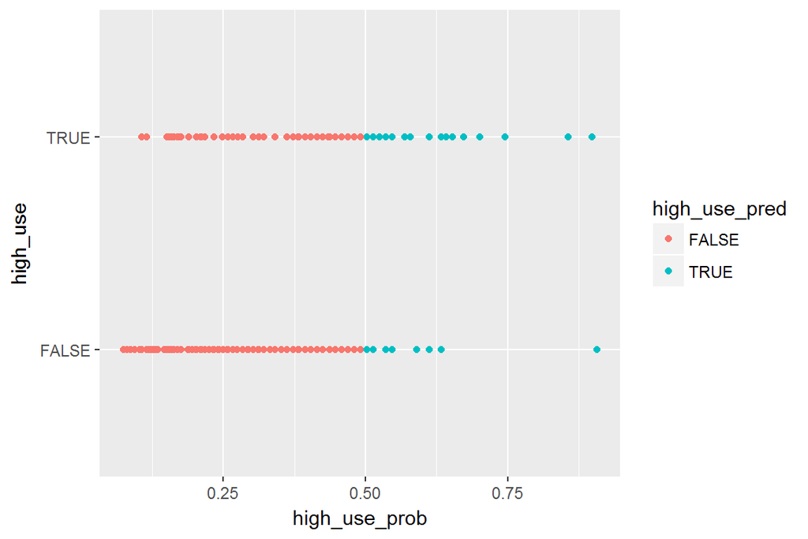

```r
# access dplyr and ggplot2
library(dplyr); library(ggplot2)

# initialize a plot of 'high_use' versus 'probability' in 'alc'
g <- ggplot(alc, aes(x = high_use_prob, y = high_use, col=high_use_pred))

# define the geom as points and draw the plot
g + geom_point()
```

```r
# tabulate the target variable versus the predictions
table(high_use = alc$high_use, prediction = alc$high_use_pred)
```

```
##         prediction
## high_use FALSE TRUE
##    FALSE   258   10
##    TRUE     88   26
```

```r
# define a loss function (mean prediction error)
loss_func <- function(class, prob) {
  n_wrong <- abs(class - prob) > 0.5
  mean(n_wrong)
}

# call loss_func to compute the average number of wrong predictions in the (training) data
loss_func(class = alc$high_use, prob = alc$high_use_pred) #proportion of wrongly predicted values.
```

```
## [1] 0.2565445
```

```r
(10+88)/382 #We get the same anwer when calculating the off diagonal values from the previous table over all values.
```

```
## [1] 0.2565445
```

```r
loss_func(class = alc$high_use, prob = 0) #comparing to simply guessing none are high users. This gives worse results than the model with absences!
```

```
## [1] 0.2984293
```

Bsed on the model including absences we actually get a lot better predictions and do not systematically end putting everyone in to the FALSE category. This model ends up falsely classifying a quarter of the data, whereas our previous model (or a directly classifying all in to the FALSE category) would end up falsely classifying one third of the students.

# Chapter 4: Clustering and classification

*Key words: k-means clustering, Euclidean distance, Manhattan distnace, standardizing, centering, scaling, linear discriminant analysis, preicting classes (training and test sets), within sum of squares*

### Boston data set

#### Introduction

The Boston data set can be loaded from the `MASS` R-package. The data is described [here](https://stat.ethz.ch/R-manual/R-devel/library/MASS/html/Boston.html). It contains infromation such as *per capita crime rate by town* and *pupil-teacher ratio by town* for the suburbs of Boston. The data frame has 506 rows (towns) and 14 columns (variables). All variables are numeric except for `rad`(=*index of accessibility to radial highways*) and `chas`(=*Charles River dummy variable: 1 if tract bounds river; 0 otherwise*) which are coded as integer variables by default. Based on summary statistics and histograms (lower) we note that all are continuous variables, except that `rad` is ordinal and `chas` a dummy variable.

```r
library(dplyr) #enables usage of pipe i.e. %<%
# access the MASS package
library(MASS)


# load the data
data("Boston")

# explore the dataset
dim(Boston)
```

```
## [1] 506  14
```

```r
str(Boston)
```

```
## 'data.frame':    506 obs. of  14 variables:
##  $ crim   : num  0.00632 0.02731 0.02729 0.03237 0.06905 ...
##  $ zn     : num  18 0 0 0 0 0 12.5 12.5 12.5 12.5 ...
##  $ indus  : num  2.31 7.07 7.07 2.18 2.18 2.18 7.87 7.87 7.87 7.87 ...
##  $ chas   : int  0 0 0 0 0 0 0 0 0 0 ...
##  $ nox    : num  0.538 0.469 0.469 0.458 0.458 0.458 0.524 0.524 0.524 0.524 ...
##  $ rm     : num  6.58 6.42 7.18 7 7.15 ...
##  $ age    : num  65.2 78.9 61.1 45.8 54.2 58.7 66.6 96.1 100 85.9 ...
##  $ dis    : num  4.09 4.97 4.97 6.06 6.06 ...
##  $ rad    : int  1 2 2 3 3 3 5 5 5 5 ...
##  $ tax    : num  296 242 242 222 222 222 311 311 311 311 ...
##  $ ptratio: num  15.3 17.8 17.8 18.7 18.7 18.7 15.2 15.2 15.2 15.2 ...
##  $ black  : num  397 397 393 395 397 ...
##  $ lstat  : num  4.98 9.14 4.03 2.94 5.33 ...
##  $ medv   : num  24 21.6 34.7 33.4 36.2 28.7 22.9 27.1 16.5 18.9 ...
```

#### Variables

Looking at the summary statistics we note that the variables are all on different scales, and that there are no missing values present and all values are positive. For the two integer variables I plotted the frequency tables, which show that the different categories within the variables are of very different sizes. Based on the pairwise plot matrix of the variables, we can see that only the variables `rm`, `nox`, `lstat` and `medv` seem somewhat normally distributed, whereas the others are highly skewed or bimodal (diagonal of the mtrix). We also note that there are some apparent linear (e.g. `nox` x `age`) as well as unlinear correlations(e.g. `nox` x `dis`) between the variables (lower triangle). Some variables don’t seem to be correlated at all on the other hand (e.g. `nox` x `chas`) (cor=0.09).

```r
# explore the dataset further
summary(Boston)
```

```
##       crim                zn             indus            chas
##  Min.   : 0.00632   Min.   :  0.00   Min.   : 0.46   Min.   :0.00000
##  1st Qu.: 0.08204   1st Qu.:  0.00   1st Qu.: 5.19   1st Qu.:0.00000
##  Median : 0.25651   Median :  0.00   Median : 9.69   Median :0.00000
##  Mean   : 3.61352   Mean   : 11.36   Mean   :11.14   Mean   :0.06917
##  3rd Qu.: 3.67708   3rd Qu.: 12.50   3rd Qu.:18.10   3rd Qu.:0.00000
##  Max.   :88.97620   Max.   :100.00   Max.   :27.74   Max.   :1.00000
##       nox               rm             age              dis
##  Min.   :0.3850   Min.   :3.561   Min.   :  2.90   Min.   : 1.130
##  1st Qu.:0.4490   1st Qu.:5.886   1st Qu.: 45.02   1st Qu.: 2.100
##  Median :0.5380   Median :6.208   Median : 77.50   Median : 3.207
##  Mean   :0.5547   Mean   :6.285   Mean   : 68.57   Mean   : 3.795
##  3rd Qu.:0.6240   3rd Qu.:6.623   3rd Qu.: 94.08   3rd Qu.: 5.188
##  Max.   :0.8710   Max.   :8.780   Max.   :100.00   Max.   :12.127
##       rad              tax           ptratio          black
##  Min.   : 1.000   Min.   :187.0   Min.   :12.60   Min.   :  0.32
##  1st Qu.: 4.000   1st Qu.:279.0   1st Qu.:17.40   1st Qu.:375.38
##  Median : 5.000   Median :330.0   Median :19.05   Median :391.44
##  Mean   : 9.549   Mean   :408.2   Mean   :18.46   Mean   :356.67
##  3rd Qu.:24.000   3rd Qu.:666.0   3rd Qu.:20.20   3rd Qu.:396.23
##  Max.   :24.000   Max.   :711.0   Max.   :22.00   Max.   :396.90
##      lstat            medv
##  Min.   : 1.73   Min.   : 5.00
##  1st Qu.: 6.95   1st Qu.:17.02
##  Median :11.36   Median :21.20
##  Mean   :12.65   Mean   :22.53
##  3rd Qu.:16.95   3rd Qu.:25.00
##  Max.   :37.97   Max.   :50.00
```

```r
table(Boston$chas); table(Boston$rad) #tables for the integer variables
```

```
##
##   0   1
## 471  35
```

```
##
##   1   2   3   4   5   6   7   8  24
##  20  24  38 110 115  26  17  24 132
```

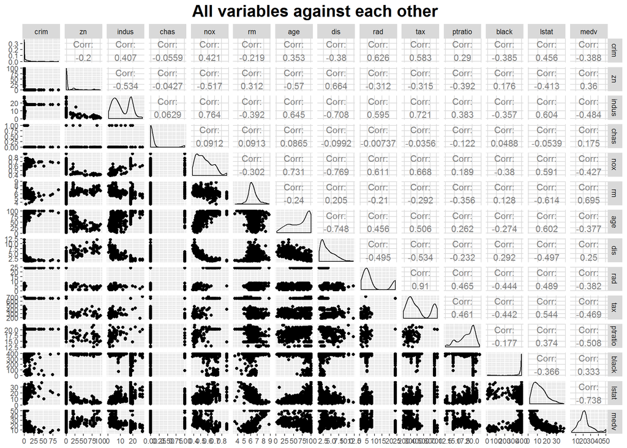

*Figure 1:Pairwise plot of all variables*

```r
# accessig the GGally and ggplot2 libraries
library(GGally)
library(ggplot2)

# Drawing pairwise plots of all columnswith ggpairs(), by sex
p <- ggpairs(Boston, lower = list(combo = wrap("facethist", bins = 20))) +
  ggtitle("All variables against each other") +
  theme(plot.title = element_text(hjust = 0.5,size=20,face='bold'))
p
```

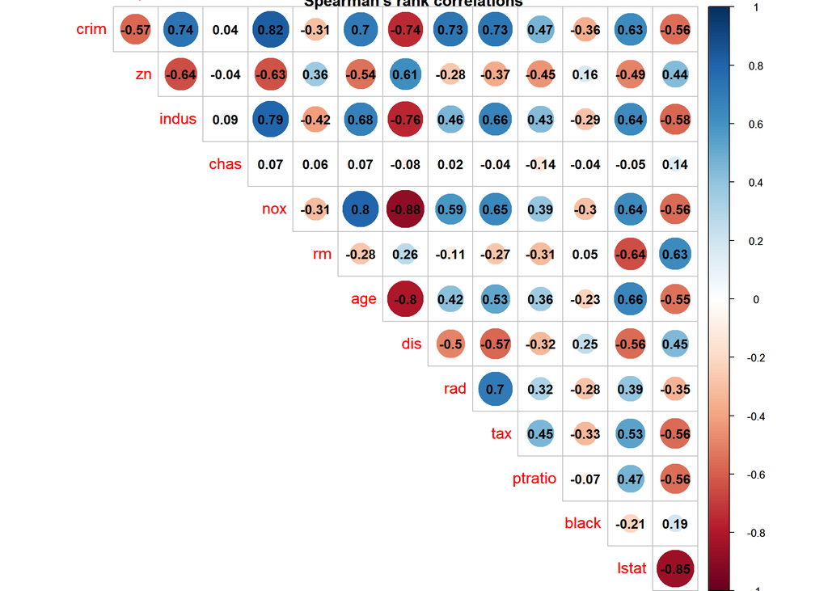

*Figure 2:Spearman’s rank correlations

```r
#Drawing the correlation matrix
#install.packages("corrplot")
library(corrplot)
cor_matrix<-cor(Boston,method="spearman") #spearman as variables not assumed to always have linear associations
corrplot(cor_matrix, method="circle",type="upper",tl.cex = 1.2,diag=F,title="Spearman's rank correlations") #my fave options
corrplot(cor_matrix, method="circle",type="upper",tl.cex = 1.2, diag=F, add=TRUE,addCoef.col="black",title="Spearman's rank correlations") #adding values to plot
```

### Data preparation for cluster analysis

#### Scaling

In cluster analysis we are interested in the distances between observations as we want to see which observations are closer to each other than the others. In order to calculate comparable distances, we need to ensure all variables are on the same scale. Hence, I scaled all the variables after which they all had a mean of zero and a standard deviation of one (see below, second summary table). Nevertheless, looking at the minimum, maximum and quartiles, it is indisputable that the variables are still very skewed (the two summary outputs below), infact their distribution plots are exactly the same as well as their pairwise correlations which can be seen from Figure 3: only the scale of the variable changes. Linear discriminant analysis, which we will soon use, actually assumes all variables to be normally distributed. So if we were to do the analysis properly we could for example rank transform the variables to normality, but we will not do this now as we will stick to the instructions of the exercise.

```r
# center and standardize variables
boston_scaled <- scale(Boston)

# summaries of the scaled variables
summary(boston_scaled) #quartiles and mean
```

```
##       crim                 zn               indus
##  Min.   :-0.419367   Min.   :-0.48724   Min.   :-1.5563
##  1st Qu.:-0.410563   1st Qu.:-0.48724   1st Qu.:-0.8668
##  Median :-0.390280   Median :-0.48724   Median :-0.2109
##  Mean   : 0.000000   Mean   : 0.00000   Mean   : 0.0000
##  3rd Qu.: 0.007389   3rd Qu.: 0.04872   3rd Qu.: 1.0150
##  Max.   : 9.924110   Max.   : 3.80047   Max.   : 2.4202
##       chas              nox                rm               age
##  Min.   :-0.2723   Min.   :-1.4644   Min.   :-3.8764   Min.   :-2.3331
##  1st Qu.:-0.2723   1st Qu.:-0.9121   1st Qu.:-0.5681   1st Qu.:-0.8366
##  Median :-0.2723   Median :-0.1441   Median :-0.1084   Median : 0.3171
##  Mean   : 0.0000   Mean   : 0.0000   Mean   : 0.0000   Mean   : 0.0000
##  3rd Qu.:-0.2723   3rd Qu.: 0.5981   3rd Qu.: 0.4823   3rd Qu.: 0.9059
##  Max.   : 3.6648   Max.   : 2.7296   Max.   : 3.5515   Max.   : 1.1164
##       dis               rad               tax             ptratio
##  Min.   :-1.2658   Min.   :-0.9819   Min.   :-1.3127   Min.   :-2.7047
##  1st Qu.:-0.8049   1st Qu.:-0.6373   1st Qu.:-0.7668   1st Qu.:-0.4876
##  Median :-0.2790   Median :-0.5225   Median :-0.4642   Median : 0.2746
##  Mean   : 0.0000   Mean   : 0.0000   Mean   : 0.0000   Mean   : 0.0000
##  3rd Qu.: 0.6617   3rd Qu.: 1.6596   3rd Qu.: 1.5294   3rd Qu.: 0.8058
##  Max.   : 3.9566   Max.   : 1.6596   Max.   : 1.7964   Max.   : 1.6372
##      black             lstat              medv
##  Min.   :-3.9033   Min.   :-1.5296   Min.   :-1.9063
##  1st Qu.: 0.2049   1st Qu.:-0.7986   1st Qu.:-0.5989
##  Median : 0.3808   Median :-0.1811   Median :-0.1449
##  Mean   : 0.0000   Mean   : 0.0000   Mean   : 0.0000
##  3rd Qu.: 0.4332   3rd Qu.: 0.6024   3rd Qu.: 0.2683
##  Max.   : 0.4406   Max.   : 3.5453   Max.   : 2.9865
```

```r
# class of the boston_scaled object
class(boston_scaled)
```

```
## [1] "matrix"
```

```r
# change the object to data frame
boston_scaled<-as.data.frame(boston_scaled)

library(pastecs)
round(stat.desc(boston_scaled),3)[c(1,4,5,8,9,13),] #printing N, min, max, med, mean, sd
```

```
##            crim      zn   indus    chas     nox      rm     age     dis
## nbr.val 506.000 506.000 506.000 506.000 506.000 506.000 506.000 506.000
## min      -0.419  -0.487  -1.556  -0.272  -1.464  -3.876  -2.333  -1.266
## max       9.924   3.800   2.420   3.665   2.730   3.552   1.116   3.957
## median   -0.390  -0.487  -0.211  -0.272  -0.144  -0.108   0.317  -0.279
## mean      0.000   0.000   0.000   0.000   0.000   0.000   0.000   0.000
## std.dev   1.000   1.000   1.000   1.000   1.000   1.000   1.000   1.000
##             rad     tax ptratio   black   lstat    medv
## nbr.val 506.000 506.000 506.000 506.000 506.000 506.000
## min      -0.982  -1.313  -2.705  -3.903  -1.530  -1.906
## max       1.660   1.796   1.637   0.441   3.545   2.987
## median   -0.522  -0.464   0.275   0.381  -0.181  -0.145
## mean      0.000   0.000   0.000   0.000   0.000   0.000
## std.dev   1.000   1.000   1.000   1.000   1.000   1.000
```

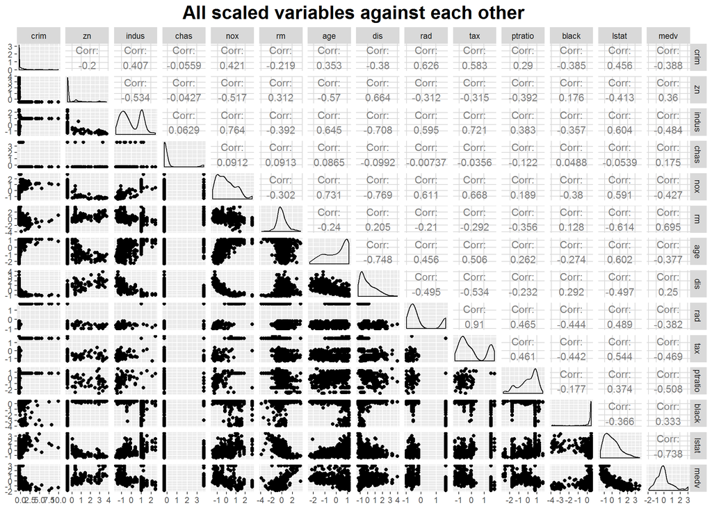

*Figure 3:Pairwise plot of all scaled variables*

```r
# accessig the GGally and ggplot2 libraries
library(GGally)
library(ggplot2)
p <- ggpairs(boston_scaled, lower = list(combo = wrap("facethist", bins = 20))) +
  ggtitle("All scaled variables against each other") +
  theme(plot.title = element_text(hjust = 0.5,size=20,face='bold'))
p
```

#### Creating the categorical crime variable

We create a categorical variable of the crime rate by using the quantiles of the scaled crime as the break points in the categorical variable. I then drop the old crime rate variable from the dataset and replace it with the new categorical one.

```r
# save the scaled crim as scaled_crim
scaled_crim <- boston_scaled$crim

# summary of the scaled_crim
summary(scaled_crim)
```

```
##      Min.   1st Qu.    Median      Mean   3rd Qu.      Max.
## -0.419400 -0.410600 -0.390300  0.000000  0.007389  9.924000
```

```r
# create a quantile vector of crim and print it
bins <- quantile(scaled_crim)
bins
```

```
##           0%          25%          50%          75%         100%
## -0.419366929 -0.410563278 -0.390280295  0.007389247  9.924109610
```

```r
# create a categorical variable 'crime'
crime <- cut(scaled_crim, breaks = bins, include.lowest = TRUE,label=c("low","med_low","med_high","high"))

# look at the table of the new factor crime
table(crime)
```

```
## crime
##      low  med_low med_high     high
##      127      126      126      127
```

```r
# remove original crim from the dataset
names(boston_scaled)
```

```
##  [1] "crim"    "zn"      "indus"   "chas"    "nox"     "rm"      "age"
##  [8] "dis"     "rad"     "tax"     "ptratio" "black"   "lstat"   "medv"
```

```r
a<-which(names(boston_scaled)=="crim")
boston_scaled<-boston_scaled[,-a]
names(boston_scaled)
```

```
##  [1] "zn"      "indus"   "chas"    "nox"     "rm"      "age"     "dis"
##  [8] "rad"     "tax"     "ptratio" "black"   "lstat"   "medv"
```

```r
# add the new categorical value to scaled data
boston_scaled$crime <- crime
names(boston_scaled)
```

```
##  [1] "zn"      "indus"   "chas"    "nox"     "rm"      "age"     "dis"
##  [8] "rad"     "tax"     "ptratio" "black"   "lstat"   "medv"    "crime"
```

#### Dividing the data in to train and test sets

I divided the data into train and test sets, so that 80% belong to the train set.

```r
set.seed(123) #setting seed to be able to acquire the exact same training and test sets later
# number of rows in the Boston dataset
n <- nrow(boston_scaled)
n
```

```
## [1] 506
```

```r
# choose randomly 80% of the rows
ind <- sample(n,  size = n * 0.8)

# create train set
train <- boston_scaled[ind,]

# create test set
test <- boston_scaled[-ind,]
```

### Linear discriminant analysis (LDA)

#### Fitting LDA fot the categorical crime variable using the train set

We employ linear discriminant analysis on the training set so that we use the categorical crime variable as the target variable and all the other 13 variables as the predictor variables. Based on the LDA-biplot the variables `zn`, `rad` and `nox` would seem to be the most important determinants when predicting in to which crime groups the observations fall.

```r
# linear discriminant analysis
lda.fit <- lda(crime~., data = train)

# print the lda.fit object
lda.fit
```

```
## Call:
## lda(crime ~ ., data = train)
##
## Prior probabilities of groups:
##       low   med_low  med_high      high
## 0.2500000 0.2475248 0.2549505 0.2475248
##
## Group means:
##                  zn      indus        chas        nox          rm
## low       0.9432005 -0.8959713 -0.11640431 -0.8577158  0.44620905
## med_low  -0.1512978 -0.3010310 -0.07547406 -0.5591764 -0.11907536
## med_high -0.4023185  0.2609362  0.18636222  0.4392319  0.04779161
## high     -0.4872402  1.0149946 -0.07547406  1.0412268 -0.50541663
##                 age        dis        rad        tax     ptratio
## low      -0.8546026  0.8232513 -0.6953230 -0.7314517 -0.45097009
## med_low  -0.3467956  0.2952511 -0.5420083 -0.4653999 -0.03350366
## med_high  0.4318874 -0.4060664 -0.4087527 -0.2821208 -0.32611400
## high      0.7952399 -0.8387924  1.6596029  1.5294129  0.80577843
##                black       lstat        medv
## low       0.37835870 -0.76633833  0.51252310
## med_low   0.32163001 -0.18506538  0.01078532
## med_high  0.08166164  0.03210543  0.15583308
## high     -0.74993410  0.87136020 -0.65964311
##
## Coefficients of linear discriminants:
##                 LD1         LD2         LD3
## zn       0.08288224  0.74545012 -1.02758413
## indus    0.03371880 -0.27414286  0.12800485
## chas    -0.07688231 -0.04569133  0.03313223
## nox      0.24620783 -0.70692830 -1.31233352
## rm      -0.13308714 -0.06060304 -0.15792484
## age      0.29339946 -0.28245910 -0.17691125
## dis     -0.04642187 -0.28428720  0.07074842
## rad      3.40029809  0.91155778 -0.10269503
## tax      0.04070331 -0.03257583  0.61283757
## ptratio  0.11422801  0.09094945 -0.21802056
## black   -0.15410658  0.03229362  0.15457698
## lstat    0.19460392 -0.28843142  0.29476658
## medv     0.17982251 -0.40689877 -0.20349106
##
## Proportion of trace:
##    LD1    LD2    LD3
## 0.9510 0.0368 0.0122
```

```r
# the function for lda biplot arrows
lda.arrows <- function(x, myscale = 1, arrow_heads = 0.1, color = "red", tex = 0.75, choices = c(1,2)){
  heads <- coef(x)
  arrows(x0 = 0, y0 = 0,
         x1 = myscale * heads[,choices[1]],
         y1 = myscale * heads[,choices[2]], col=color, length = arrow_heads)
  text(myscale * heads[,choices], labels = row.names(heads),
       cex = tex, col=color, pos=3)
}

# target classes as numeric
str(train$crime)
```

```
##  Factor w/ 4 levels "low","med_low",..: 3 4 2 4 3 3 3 4 1 3 ...
```

```r
classes <- as.numeric(train$crime)
str(classes)
```

```
##  num [1:404] 3 4 2 4 3 3 3 4 1 3 ...
```

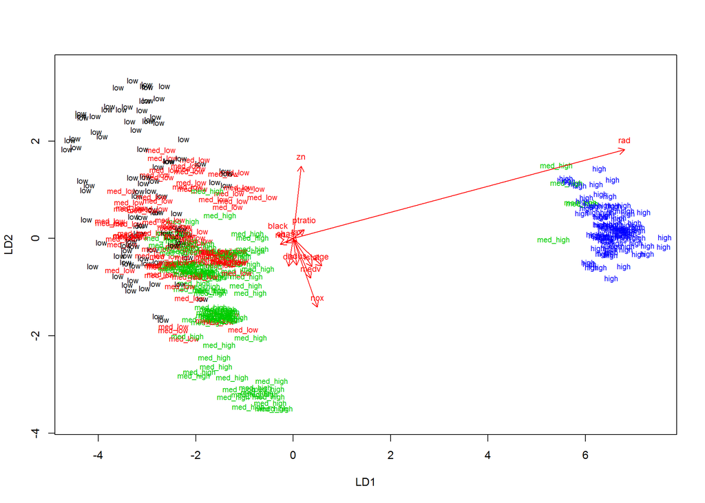

*Figure 4:LDA biplot for training set*

```r
# plot the lda results
plot(lda.fit, dimen = 2,col=classes, pch=classes)
lda.arrows(lda.fit, myscale = 2) #myscale determines the length og the arrows
```

#### Prediction in test set and performance assessment

With the test set (20% of the original data) we test how well the fitted LDA model we created using the training set (80% of the data) performs. We note that the mean prection error is just below 30%.

```r
# save the correct classes from test data
correct_classes <- test$crime

# remove the crime variable from test data
test <- dplyr::select(test, -crime)

# lda.fit, correct_classes and test are available

# predict classes with test data
lda.pred <- predict(lda.fit, newdata = test)

# cross tabulate the results
t<-table(correct = correct_classes, predicted = lda.pred$class);t
```

```
##           predicted
## correct    low med_low med_high high
##   low       16      10        0    0
##   med_low    7      15        4    0
##   med_high   1       6       15    1
##   high       0       0        1   26
```

```r
#To calculate the predictive power we calculate the mean prediction error which means the proportion wrongly classifyed values:
(sum(t)-sum(diag(t)))/sum(t)
```

```
## [1] 0.2941176
```

### K-means clustering

K-means clustering is the oldest most commonly used clustering method as it often finds a solution as is easy to use. Nevertheless, it isn’t very robust: any changes in the dataset may result in different solutions.

#### Distances between observations

We calculate the euclidian and manhattan distances between the observations. We note that their ranges are very different.

```r
set.seed(123)

# euclidean distance matrix
Boston_scaled<-scale(Boston)
dist_eu <- dist(Boston_scaled)
summary(dist_eu)
```

```
##    Min. 1st Qu.  Median    Mean 3rd Qu.    Max.
##  0.1343  3.4620  4.8240  4.9110  6.1860 14.4000
```

```r
# manhattan distance matrix
dist_man <- dist(Boston_scaled,method="manhattan")
summary(dist_man)
```

```
##    Min. 1st Qu.  Median    Mean 3rd Qu.    Max.
##  0.2662  8.4830 12.6100 13.5500 17.7600 48.8600
```

#### Optimal number of clusters via K-means clustering

We continue with the commonly used euclidian distances to complete k-means clustering. First starting off with four clusters we note from the pairwise scatterplot which is coloured based on cluster, that the green and red clusters are perhaps the most important clusters regarding the majority of the variables.

```r
# k-means clustering
km4 <-kmeans(dist_eu, centers = 4)
summary(km4)
```

```
##              Length Class  Mode
## cluster       506   -none- numeric
## centers      2024   -none- numeric
## totss           1   -none- numeric
## withinss        4   -none- numeric
## tot.withinss    1   -none- numeric
## betweenss       1   -none- numeric
## size            4   -none- numeric
## iter            1   -none- numeric
## ifault          1   -none- numeric
```

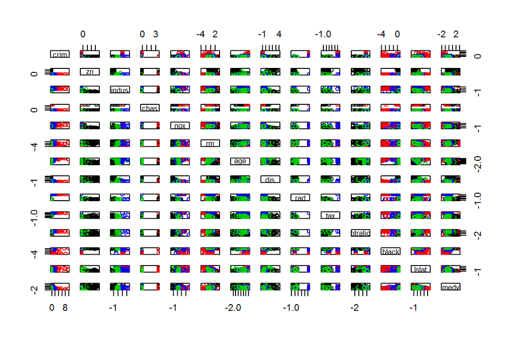

```r
# plot the Boston dataset with clusters
pairs(Boston_scaled, col = km4$cluster)
```

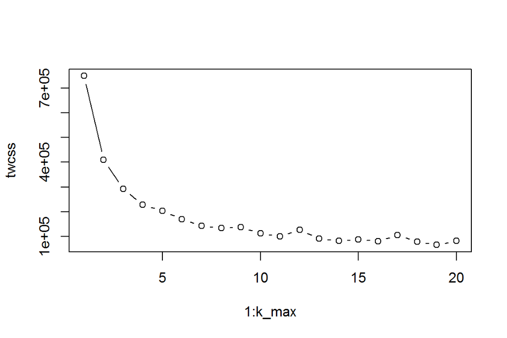

```r
# determine the number of clusters
k_max <- 20

# calculate the total within sum of squares
twcss <- sapply(1:k_max, function(k){kmeans(dist_eu, k)$tot.withinss})

# visualize the results
plot(1:k_max, twcss, type='b') #shows that 2 is the optimal amount of clusters
```

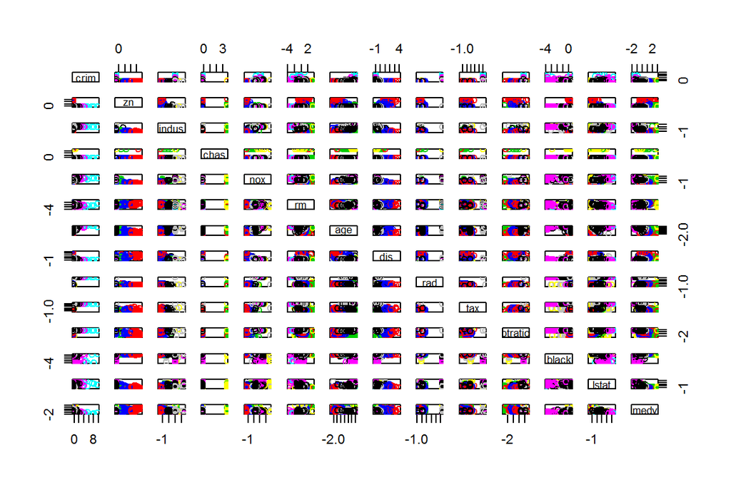

```r
# k-means clustering
km9 <-kmeans(dist_eu, centers = 9)

# plot the Boston dataset with clusters
pairs(Boston_scaled, col = km9$cluster)
```

To assess the optimal amount of clusters, i calculated the total within sum of squares for the k-means results from 1 to 20 clusters. The total within sum of squares is the total of all the within cluster sum of squares (WCSS), which is calculated as follows: $WCSS=\sum_{i=1}^N (x_i=c)^2$, where $c$ is the centroid of the $i$th cluster.

Plotting these, we note that four to nine clusters would suffice (*annoyingly, I had forgot to put a seed so the situation looks different now*). There is no clear cutoff this time, so it is highly subjective and would depend on the aims of the study and the background theory. I chose nine clusters, as after that based on the twcss x nclusters plot, it is clear that there is no gain of adding more clusters, in other words (nearly) no more of the variance of the observations is explained by additional clusters (the total distance of the observations from the centroids of the clusters is not reduced by the addition of more clusters). Also, as I had already ran the 4 clusters solution I thought this would provide an interesting comparison. Thus, I reran the k-means clustering and based on the pairwise plot we can see that the differently coloured clusters seem to be seperating the observations quite nicely.

```r
table(km4$cluster)
```

```
##
##   1   2   3   4
## 107  66 218 115
```

```r
table(km9$cluster)
```

```
##
##   1   2   3   4   5   6   7   8   9
## 115  44  45 108   5  43  29  48  69
```

```r
data<-cbind(km9$cluster,km4$cluster)
data<-as.data.frame(data)
names(data)<-c("clusters_9","clusters_4")

str(data)
```

```
## 'data.frame':    506 obs. of  2 variables:
##  $ clusters_9: int  4 1 4 4 4 4 1 1 8 1 ...
##  $ clusters_4: int  3 3 3 3 3 3 3 3 3 3 ...
```

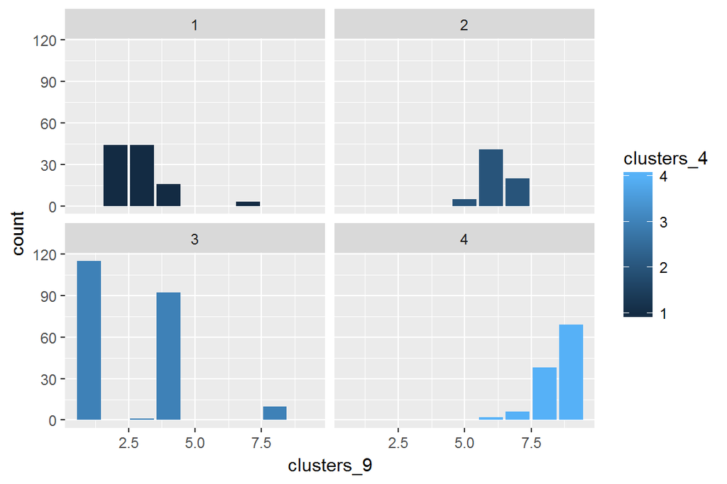

```r
g1<-ggplot(data=data, aes(x=clusters_9,fill=clusters_4))
g1+geom_bar()+facet_wrap("clusters_4")
```

# Chapter 5: Dimentionality reduction techniques

*Key words: principal component analysis (PCA), multiple correspondance analysis (MCA), biplots*

### Human data set

#### Introduction

I have created the `human` data set from two openly available data sets which originate from the [United Nations Development Programme](http://hdr.undp.org/en/content/human-development-index-hdi). My scripts for the creation of the data can be found [here](https://github.com/JadwigaBuchwald/IODS-project/blob/master/data/create_human.R). An overview of the indices the data contain can be found [here](http://hdr.undp.org/sites/default/files/hdr2015_technical_notes.pdf).

Let’s take a closer look at the data I have created.

```r
library(dplyr) #enables usage of pipe i.e. %<%

#reading in the data and exploring it
setwd("C:/HY-Data/JADWIGAB/PhD_FIMM/NotesOutsideTheOffice/Courses/OpenData2017/For_IODS/IODS-project/data")
human<-read.table("./human.txt",sep="\t", header=T, dec=".",stringsAsFactors = FALSE)
dim(human) #155 x 8
```

```
## [1] 155   8
```

```r
names(human)
```

```
## [1] "Sec.Edu.FMRatio"     "LabourForce.FMRatio" "Eduyears.Exp"
## [4] "Life.Exp"            "GNI"                 "Mat.Mort.Ratio"
## [7] "Adol.Birth.Rate"     "Parl.F.Prcnt"
```

```r
head(human)
```

```
##             Sec.Edu.FMRatio LabourForce.FMRatio Eduyears.Exp Life.Exp
## Norway            1.0072389           0.8908297         17.5     81.6
## Australia         0.9968288           0.8189415         20.2     82.4
## Switzerland       0.9834369           0.8251001         15.8     83.0
## Denmark           0.9886128           0.8840361         18.7     80.2
## Netherlands       0.9690608           0.8286119         17.9     81.6
## Germany           0.9927835           0.8072289         16.5     80.9
##               GNI Mat.Mort.Ratio Adol.Birth.Rate Parl.F.Prcnt
## Norway      64992              4             7.8         39.6
## Australia   42261              6            12.1         30.5
## Switzerland 56431              6             1.9         28.5
## Denmark     44025              5             5.1         38.0
## Netherlands 45435              6             6.2         36.9
## Germany     43919              7             3.8         36.9
```

```r
str(human)
```

```
## 'data.frame':    155 obs. of  8 variables:
##  $ Sec.Edu.FMRatio    : num  1.007 0.997 0.983 0.989 0.969 ...
##  $ LabourForce.FMRatio: num  0.891 0.819 0.825 0.884 0.829 ...
##  $ Eduyears.Exp       : num  17.5 20.2 15.8 18.7 17.9 16.5 18.6 16.5 15.9 19.2 ...
##  $ Life.Exp           : num  81.6 82.4 83 80.2 81.6 80.9 80.9 79.1 82 81.8 ...
##  $ GNI                : int  64992 42261 56431 44025 45435 43919 39568 52947 42155 32689 ...
##  $ Mat.Mort.Ratio     : int  4 6 6 5 6 7 9 28 11 8 ...
##  $ Adol.Birth.Rate    : num  7.8 12.1 1.9 5.1 6.2 3.8 8.2 31 14.5 25.3 ...
##  $ Parl.F.Prcnt       : num  39.6 30.5 28.5 38 36.9 36.9 19.9 19.4 28.2 31.4 ...
```

All in all the data contains 155 observations (countries) and 8 (numeric or integer) variables as all rows with missing values have been deleted and only the following variables have been included:

1. *Sec.Edu.FMRatio* = Ratio of the proportion of females (>=25 years old) with at least secondary education to that of males
2. *LabourForce.FMRatio* = Ratio of the proportion of females (>=15 years old) in the labour force to that of males
3. *Eduyears.Exp* = Expected years of schooling
4. *Life.Exp* = Life expectancy at birth
5. *GNI* = Gross National Income per capita
6. *Mat.Mort.Ratio* = Maternal mortality ratio (deaths per100,000 live births)
7. *Adol.Birth.Rate* = Adolescent birth rate (births per 1,000 women ages 15-19)
8. *Parl.F.Prcnt* = Percentage of female representatives in the parliament

#### Variables

```r
# explore the dataset further
summary(human)
```

```
##  Sec.Edu.FMRatio  LabourForce.FMRatio  Eduyears.Exp      Life.Exp
##  Min.   :0.1717   Min.   :0.1857      Min.   : 5.40   Min.   :49.00
##  1st Qu.:0.7264   1st Qu.:0.5984      1st Qu.:11.25   1st Qu.:66.30
##  Median :0.9375   Median :0.7535      Median :13.50   Median :74.20
##  Mean   :0.8529   Mean   :0.7074      Mean   :13.18   Mean   :71.65
##  3rd Qu.:0.9968   3rd Qu.:0.8535      3rd Qu.:15.20   3rd Qu.:77.25
##  Max.   :1.4967   Max.   :1.0380      Max.   :20.20   Max.   :83.50
##       GNI         Mat.Mort.Ratio   Adol.Birth.Rate   Parl.F.Prcnt
##  Min.   :   581   Min.   :   1.0   Min.   :  0.60   Min.   : 0.00
##  1st Qu.:  4198   1st Qu.:  11.5   1st Qu.: 12.65   1st Qu.:12.40
##  Median : 12040   Median :  49.0   Median : 33.60   Median :19.30
##  Mean   : 17628   Mean   : 149.1   Mean   : 47.16   Mean   :20.91
##  3rd Qu.: 24512   3rd Qu.: 190.0   3rd Qu.: 71.95   3rd Qu.:27.95
##  Max.   :123124   Max.   :1100.0   Max.   :204.80   Max.   :57.50
```

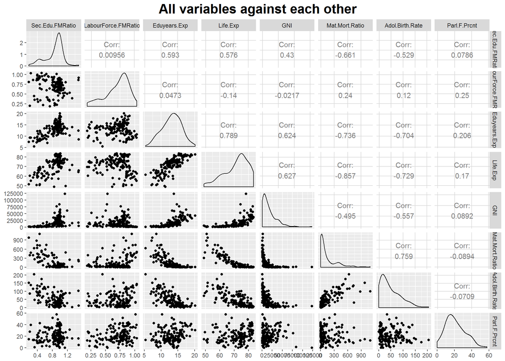

*Figure 1:Pairwise plot of all variables*

```r
# accessig the GGally and ggplot2 libraries
library(GGally)
library(ggplot2)

# Drawing pairwise plots of all columnswith ggpairs(), by country
p <- ggpairs(human) +
  ggtitle("All variables against each other") +
  theme(plot.title = element_text(hjust = 0.5,size=20,face='bold'))
p
```

### Principal component analyss

Principal component analysis is a commonly used method for dimention reduction of data. All derived principal components (PC) are uncorrelated from each other and each PC captures less variance of the data than the previous PC.

#### Before standardization

Let’s see what kind of results we get when we perform principal component analysis on our data before we standardize the variables. In general this is not a good idea as PCA is sensitive to the relative scaling of the original variables and assumes that variables with larger variance are more important than those with a smaller variance. We will do this as a exercise to see how the results change when we later perform PCA on standardized variables.

```r
# perform principal component analysis (with the SVD method)
pca_human <- prcomp(human)
# create and print out a summary of pca_human
s <- summary(pca_human)
s
```

```
## Importance of components:
##                              PC1      PC2   PC3   PC4   PC5   PC6    PC7
## Standard deviation     1.854e+04 185.5219 25.19 11.45 3.766 1.566 0.1912
## Proportion of Variance 9.999e-01   0.0001  0.00  0.00 0.000 0.000 0.0000
## Cumulative Proportion  9.999e-01   1.0000  1.00  1.00 1.000 1.000 1.0000
##                           PC8
## Standard deviation     0.1591
## Proportion of Variance 0.0000
## Cumulative Proportion  1.0000
```

```r
pca_pr <- round(100*s$importance[2, ], digits = 1)
pca_pr
```

```
## PC1 PC2 PC3 PC4 PC5 PC6 PC7 PC8
## 100   0   0   0   0   0   0   0
```

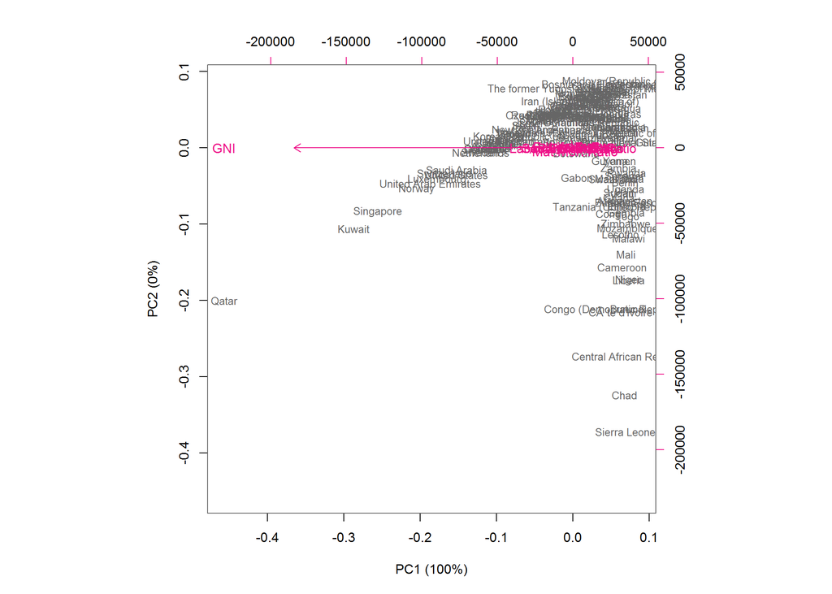

*Figure 2: Biplot of the two first principal components obtained before standardizing the variables. The first PC explains all of the total variance in the 8 original variables and is characterized by the variable GNI alone.*

```r
# create object pc_lab to be used as axis labels
pc_lab<-paste0(names(pca_pr), " (", pca_pr, "%)")

# drawing a biplot of the PCA representation of the original variables
biplot(pca_human, cex = c(0.8, 1), col = c("grey40", "deeppink2"), xlab = pc_lab[1], ylab = pc_lab[2])
```

```r
library(pastecs)
round(stat.desc(human),3)[c(1,4,5,8,9,13),] #printing N, min, max, med, mean, sd, as the above solutions suggests GNI has a lot bigger sd^2 than the rest of the variables-->indeed it does.
```

```
##         Sec.Edu.FMRatio LabourForce.FMRatio Eduyears.Exp Life.Exp
## nbr.val         155.000             155.000      155.000  155.000
## min               0.172               0.186        5.400   49.000
## max               1.497               1.038       20.200   83.500
## median            0.938               0.753       13.500   74.200
## mean              0.853               0.707       13.176   71.654
## std.dev           0.242               0.199        2.840    8.332
##               GNI Mat.Mort.Ratio Adol.Birth.Rate Parl.F.Prcnt
## nbr.val    155.00        155.000         155.000      155.000
## min        581.00          1.000           0.600        0.000
## max     123124.00       1100.000         204.800       57.500
## median   12040.00         49.000          33.600       19.300
## mean     17627.90        149.084          47.159       20.912
## std.dev  18543.85        211.790          41.112       11.488
```

We end up obtaining one PC which explains pretty much all (that is, after rounding 100%) of the variance of the 8 variables in the data. Looking at the biplot we see that the variable GNI is most influencial and ends up defining PC1 while no other variable seems to matter. This variable has the gratest range and variance of all the variables. Thus it ends up getting too much weight in the analysis and the results can not be trusted as the importance of the variables using this method are not comparable without scaling. We will next redo the PCA after first scaling the variables.

#### After standardization

Let’s begin by scaling the variables.

```r
# center and standardize variables
human_std<- scale(human)

# summaries of the scaled variables
summary(human_std) #quartiles and mean
```

```
##  Sec.Edu.FMRatio   LabourForce.FMRatio  Eduyears.Exp        Life.Exp
##  Min.   :-2.8189   Min.   :-2.6247     Min.   :-2.7378   Min.   :-2.7188
##  1st Qu.:-0.5233   1st Qu.:-0.5484     1st Qu.:-0.6782   1st Qu.:-0.6425
##  Median : 0.3503   Median : 0.2316     Median : 0.1140   Median : 0.3056
##  Mean   : 0.0000   Mean   : 0.0000     Mean   : 0.0000   Mean   : 0.0000
##  3rd Qu.: 0.5958   3rd Qu.: 0.7350     3rd Qu.: 0.7126   3rd Qu.: 0.6717
##  Max.   : 2.6646   Max.   : 1.6632     Max.   : 2.4730   Max.   : 1.4218
##       GNI          Mat.Mort.Ratio    Adol.Birth.Rate    Parl.F.Prcnt
##  Min.   :-0.9193   Min.   :-0.6992   Min.   :-1.1325   Min.   :-1.8203
##  1st Qu.:-0.7243   1st Qu.:-0.6496   1st Qu.:-0.8394   1st Qu.:-0.7409
##  Median :-0.3013   Median :-0.4726   Median :-0.3298   Median :-0.1403
##  Mean   : 0.0000   Mean   : 0.0000   Mean   : 0.0000   Mean   : 0.0000
##  3rd Qu.: 0.3712   3rd Qu.: 0.1932   3rd Qu.: 0.6030   3rd Qu.: 0.6127
##  Max.   : 5.6890   Max.   : 4.4899   Max.   : 3.8344   Max.   : 3.1850
```

```r
# class of the boston_scaled object
class(human_std)
```

```
## [1] "matrix"
```

```r
human_std<-as.data.frame(human_std)
#
library(pastecs)
round(stat.desc(human_std),3)[c(1,4,5,8,9,13),] #printing N, min, max, med, mean, sd
```

```
##         Sec.Edu.FMRatio LabourForce.FMRatio Eduyears.Exp Life.Exp     GNI
## nbr.val         155.000             155.000      155.000  155.000 155.000
## min              -2.819              -2.625       -2.738   -2.719  -0.919
## max               2.665               1.663        2.473    1.422   5.689
## median            0.350               0.232        0.114    0.306  -0.301
## mean              0.000               0.000        0.000    0.000   0.000
## std.dev           1.000               1.000        1.000    1.000   1.000
##         Mat.Mort.Ratio Adol.Birth.Rate Parl.F.Prcnt
## nbr.val        155.000         155.000      155.000
## min             -0.699          -1.132       -1.820
## max              4.490           3.834        3.185
## median          -0.473          -0.330       -0.140
## mean             0.000           0.000        0.000
## std.dev          1.000           1.000        1.000
```

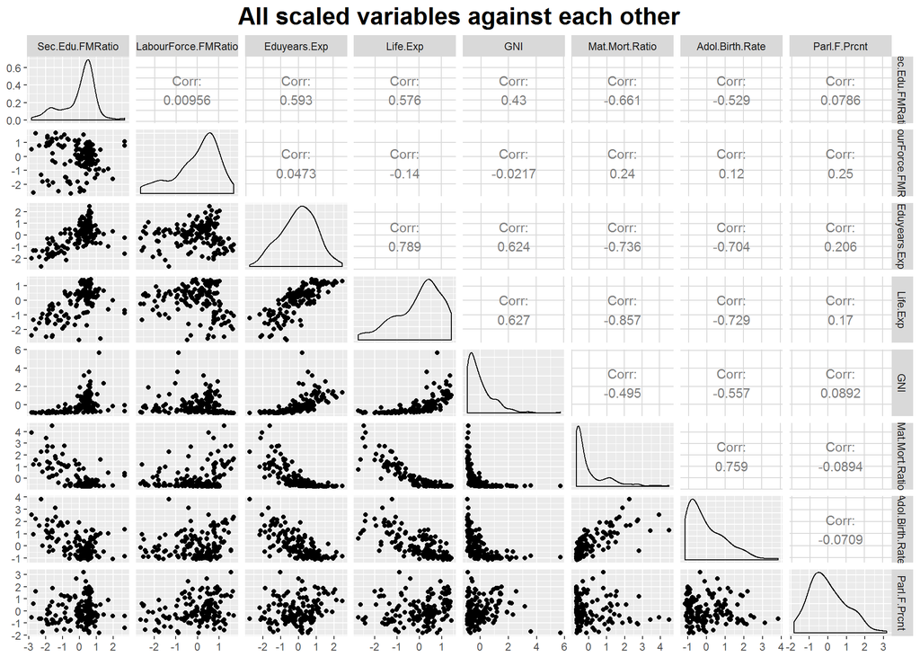

*Figure 3:Pairwise plot of all scaled variables*

```r
#

p <- ggpairs(human_std)+ ggtitle("All scaled variables against each other") +
   theme(plot.title = element_text(hjust = 0.5,size=20,face='bold'))
p
```

Now, all variables have a mean of 0 and standard deviation of 1. The distributions are still of the same shape though as before (e.g. diagonal of the pairwise plots before and after scaling) and are still not normal (e.g. median is not equel to mean after scaling either). The relationships between the variables can also be seen to have remained identical. Only thing that has changes is the range: the minima and maxima and the meand and variance (sd^2).

Let’s employ PCA on the scaled data.

```r
# perform principal component analysis (with the SVD method)
pca_human_std <- prcomp(human_std)
# create and print out a summary of pca_human
s <- summary(pca_human_std)
s
```

```
## Importance of components:
##                           PC1    PC2     PC3     PC4     PC5     PC6
## Standard deviation     2.0708 1.1397 0.87505 0.77886 0.66196 0.53631
## Proportion of Variance 0.5361 0.1624 0.09571 0.07583 0.05477 0.03595
## Cumulative Proportion  0.5361 0.6984 0.79413 0.86996 0.92473 0.96069
##                            PC7     PC8
## Standard deviation     0.45900 0.32224
## Proportion of Variance 0.02634 0.01298
## Cumulative Proportion  0.98702 1.00000
```

```r
pca_pr_std <- round(100*s$importance[2, ], digits = 1)
pca_pr_std
```

```
##  PC1  PC2  PC3  PC4  PC5  PC6  PC7  PC8
## 53.6 16.2  9.6  7.6  5.5  3.6  2.6  1.3
```

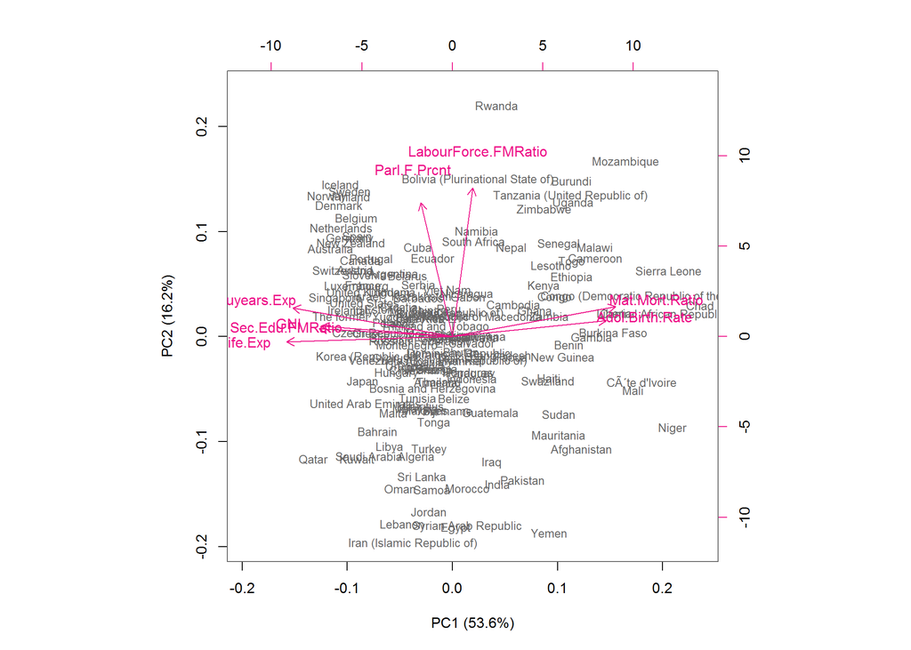

*Figure 4:Biplot of the two first principal components obtained after standardizing the variables. The first PC explains over half of the total variance in the 8 original variables, and depicts the health care and educational aspects, while the second PC explains less than one fifth of the total variance and depicts the political gender equality*

```r
# create object pc_lab to be used as axis labels
pc_lab<-paste0(names(pca_pr_std), " (", pca_pr_std, "%)")

# drawing a biplot of the PCA representation of the original variables
biplot(pca_human_std, cex = c(0.8, 1), col = c("grey40", "deeppink2"), xlab = pc_lab[1], ylab = pc_lab[2])
```

Now, based on the summary of the PCA and the biplot of the first two PCs we seem to have obtained more sensible results. The first PC explains over half of the total variance of the 8 variables, and together with the second one it explains around 70%.

#### Interpreting the biplot obtained after tandardization

The biplot shows that the variables `LabourFrce.FMRatio` and `Prl.F.Prcnt` load on to the PC2 while all the rest contribute mainly to PC1. Therefore, PC1 would seem to depict health care and educational aspects while the second PC gender equality in the political system. Countries that fall in the top left quarter of the plot are the ones that get the desired scores on these dimensions, whereas those in the right bottom are the ones that get the scores least respected. The two PCs are uncorrelated while the variables within a PC are highly correlated (either positively or negatively).

### Tea data set

#### Exploring the data

```r
#install.packages("FactoMineR")
library(FactoMineR) #conatins the data set tea
data(tea) #loading the data tea
library(ggplot2)
#install.packages("tidyr")
library(tidyr)

# look at the summaries and structure of the data
summary(tea)
```

```
##          breakfast           tea.time          evening          lunch
##  breakfast    :144   Not.tea time:131   evening    :103   lunch    : 44
##  Not.breakfast:156   tea time    :169   Not.evening:197   Not.lunch:256
##
##
##
##
##
##         dinner           always          home           work
##  dinner    : 21   always    :103   home    :291   Not.work:213
##  Not.dinner:279   Not.always:197   Not.home:  9   work    : 87
##
##
##
##
##
##         tearoom           friends          resto          pub
##  Not.tearoom:242   friends    :196   Not.resto:221   Not.pub:237
##  tearoom    : 58   Not.friends:104   resto    : 79   pub    : 63
##
##
##
##
##
##         Tea         How           sugar                     how
##  black    : 74   alone:195   No.sugar:155   tea bag           :170
##  Earl Grey:193   lemon: 33   sugar   :145   tea bag+unpackaged: 94
##  green    : 33   milk : 63                  unpackaged        : 36
##                  other:  9
##
##
##
##                   where                 price          age        sex
##  chain store         :192   p_branded      : 95   Min.   :15.00   F:178
##  chain store+tea shop: 78   p_cheap        :  7   1st Qu.:23.00   M:122
##  tea shop            : 30   p_private label: 21   Median :32.00
##                             p_unknown      : 12   Mean   :37.05
##                             p_upscale      : 53   3rd Qu.:48.00
##                             p_variable     :112   Max.   :90.00
##
```

[output cut: 25 more lines]

```
##  feminine    :129   Not.sophisticated: 85   No.slimming:255
##  Not.feminine:171   sophisticated    :215   slimming   : 45
##
##
##
##
##
##         exciting          relaxing              effect.on.health
##  exciting   :116   No.relaxing:113   effect on health   : 66
##  No.exciting:184   relaxing   :187   No.effect on health:234
##
##
##
##
##
```

```r
str(tea)
```

```
## 'data.frame':    300 obs. of  36 variables:
##  $ breakfast       : Factor w/ 2 levels "breakfast","Not.breakfast": 1 1 2 2 1 2 1 2 1 1 ...
##  $ tea.time        : Factor w/ 2 levels "Not.tea time",..: 1 1 2 1 1 1 2 2 2 1 ...
##  $ evening         : Factor w/ 2 levels "evening","Not.evening": 2 2 1 2 1 2 2 1 2 1 ...
##  $ lunch           : Factor w/ 2 levels "lunch","Not.lunch": 2 2 2 2 2 2 2 2 2 2 ...
##  $ dinner          : Factor w/ 2 levels "dinner","Not.dinner": 2 2 1 1 2 1 2 2 2 2 ...
##  $ always          : Factor w/ 2 levels "always","Not.always": 2 2 2 2 1 2 2 2 2 2 ...
##  $ home            : Factor w/ 2 levels "home","Not.home": 1 1 1 1 1 1 1 1 1 1 ...
##  $ work            : Factor w/ 2 levels "Not.work","work": 1 1 2 1 1 1 1 1 1 1 ...
##  $ tearoom         : Factor w/ 2 levels "Not.tearoom",..: 1 1 1 1 1 1 1 1 1 2 ...
##  $ friends         : Factor w/ 2 levels "friends","Not.friends": 2 2 1 2 2 2 1 2 2 2 ...
##  $ resto           : Factor w/ 2 levels "Not.resto","resto": 1 1 2 1 1 1 1 1 1 1 ...
##  $ pub             : Factor w/ 2 levels "Not.pub","pub": 1 1 1 1 1 1 1 1 1 1 ...
##  $ Tea             : Factor w/ 3 levels "black","Earl Grey",..: 1 1 2 2 2 2 2 1 2 1 ...
##  $ How             : Factor w/ 4 levels "alone","lemon",..: 1 3 1 1 1 1 1 3 3 1 ...
```

[output cut: 22 more lines]

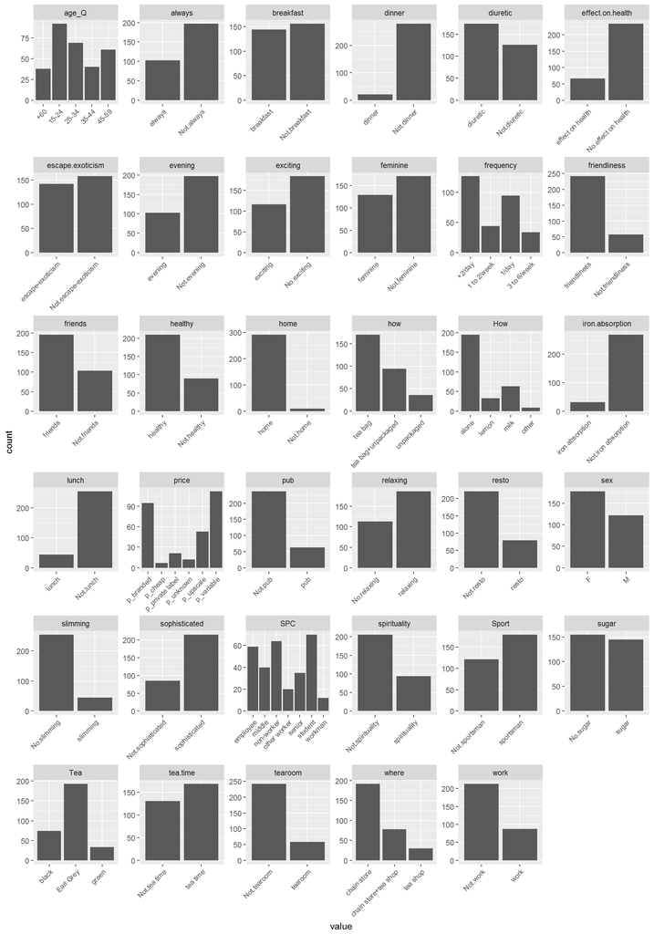

*Figure 5:Barplots of tea variables*

```r
tea<-dplyr::select(tea,-age)

#we take age away as age_Q will suffice
gather(tea) %>% ggplot(aes(value)) + facet_wrap("key", scales = "free") +geom_bar() +theme(axis.text.x=element_text(angle=45,hjust=1,size=8))
```

#### Multiple Correspondance Analysis

Multiple Correspondance analysis is a suitable dimention reduction technique when we have categorical variables, which is the case with the tea data. Below we note that the first dimention only explains 6% of the variance in the data. When we draw the biplot, as there are so many variables and categories within the plot becomes quite messy. Once we only draw labels for the 20 categories that contribute most on the two dimensions displayed the plot becomes more readable. The categories are from multiple variables showing that not only a few variables are very important but that many variables have atleast some categories that are very influencial.

```r
# multiple correspondence analysis
mca <- MCA(tea, graph = FALSE)

# summary of the model
summary(mca)
```

```
##
## Call:
## MCA(X = tea, graph = FALSE)
##
##
## Eigenvalues
##                        Dim.1   Dim.2   Dim.3   Dim.4   Dim.5   Dim.6
## Variance               0.090   0.082   0.070   0.063   0.056   0.053
## % of var.              5.838   5.292   4.551   4.057   3.616   3.465
## Cumulative % of var.   5.838  11.130  15.681  19.738  23.354  26.819
##                        Dim.7   Dim.8   Dim.9  Dim.10  Dim.11  Dim.12
## Variance               0.050   0.048   0.047   0.044   0.041   0.040
## % of var.              3.272   3.090   3.053   2.834   2.643   2.623
## Cumulative % of var.  30.091  33.181  36.234  39.068  41.711  44.334
##                       Dim.13  Dim.14  Dim.15  Dim.16  Dim.17  Dim.18
## Variance               0.039   0.037   0.036   0.035   0.034   0.032
## % of var.              2.531   2.388   2.302   2.275   2.172   2.085
## Cumulative % of var.  46.865  49.252  51.554  53.829  56.000  58.086
##                       Dim.19  Dim.20  Dim.21  Dim.22  Dim.23  Dim.24
## Variance               0.031   0.031   0.030   0.028   0.027   0.026
## % of var.              2.013   2.011   1.915   1.847   1.740   1.686
## Cumulative % of var.  60.099  62.110  64.025  65.872  67.611  69.297
##                       Dim.25  Dim.26  Dim.27  Dim.28  Dim.29  Dim.30
## Variance               0.025   0.025   0.024   0.024   0.023   0.022
## % of var.              1.638   1.609   1.571   1.524   1.459   1.425
## Cumulative % of var.  70.935  72.544  74.115  75.639  77.099  78.523
##                       Dim.31  Dim.32  Dim.33  Dim.34  Dim.35  Dim.36
## Variance               0.021   0.020   0.020   0.019   0.019   0.018
## % of var.              1.378   1.322   1.281   1.241   1.222   1.152
## Cumulative % of var.  79.901  81.223  82.504  83.745  84.967  86.119
##                       Dim.37  Dim.38  Dim.39  Dim.40  Dim.41  Dim.42
## Variance               0.017   0.017   0.016   0.015   0.015   0.014
## % of var.              1.092   1.072   1.019   0.993   0.950   0.924
## Cumulative % of var.  87.211  88.283  89.301  90.294  91.244  92.169
##                       Dim.43  Dim.44  Dim.45  Dim.46  Dim.47  Dim.48
## Variance               0.014   0.013   0.012   0.011   0.011   0.010
## % of var.              0.891   0.833   0.792   0.729   0.716   0.666
## Cumulative % of var.  93.060  93.893  94.684  95.414  96.130  96.796
##                       Dim.49  Dim.50  Dim.51  Dim.52  Dim.53  Dim.54
## Variance               0.010   0.009   0.009   0.008   0.007   0.006
```

[output cut: 48 more lines]

```
## dinner        |  0.796  1.805  0.048  3.777 |
## Not.dinner    | -0.060  0.136  0.048 -3.777 |
##
## Categorical variables (eta2)
##                 Dim.1 Dim.2 Dim.3
## breakfast     | 0.031 0.000 0.011 |
## tea.time      | 0.240 0.000 0.003 |
## evening       | 0.040 0.087 0.062 |
## lunch         | 0.062 0.029 0.010 |
## dinner        | 0.092 0.000 0.048 |
## always        | 0.056 0.035 0.007 |
## home          | 0.016 0.002 0.030 |
## work          | 0.075 0.020 0.022 |
## tearoom       | 0.321 0.019 0.031 |
## friends       | 0.186 0.061 0.030 |
```

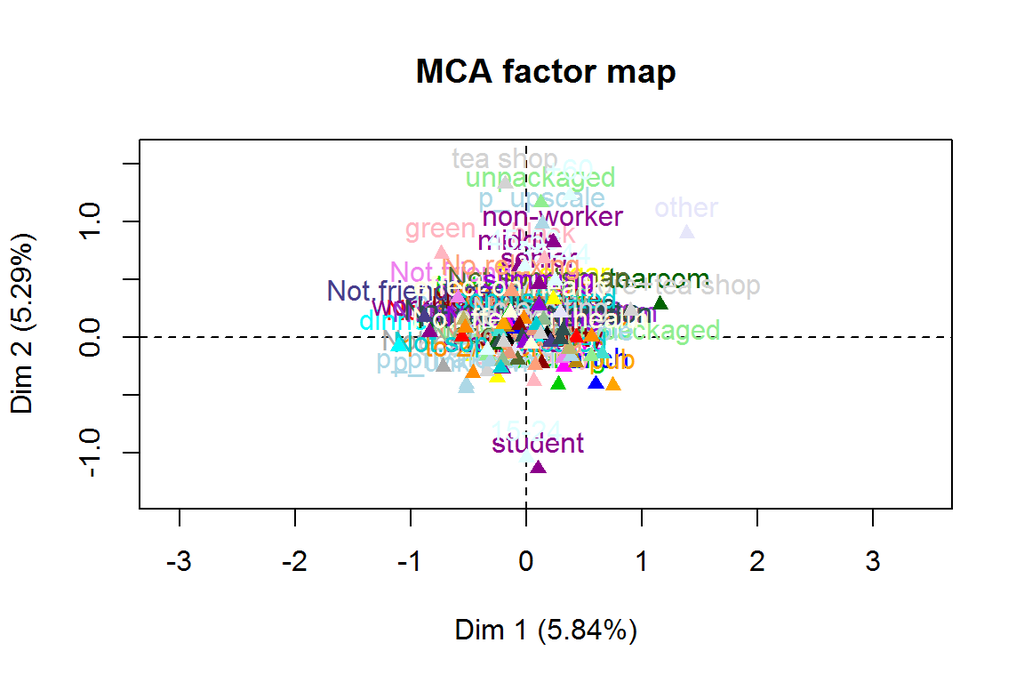

```r
# visualize MCA
plot(mca, invisible=c("ind"),habillage="quali")
```

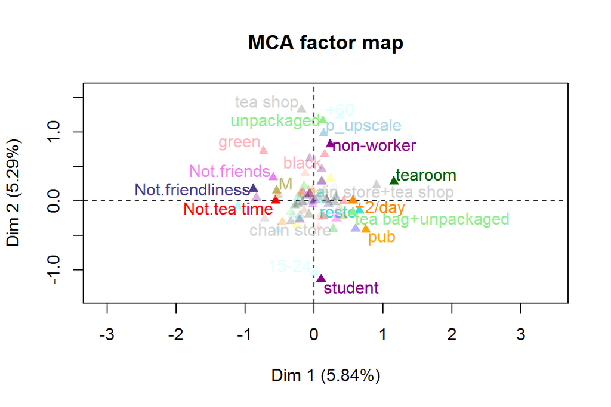

```r
#Only plotting labels for the 20 categories that contribute most
plot(mca, invisible=c("ind"),habillage="quali", selectMod="contrib 20")
```